# Binary Classification of Insurance Cross Selling 💼🔍

### 💡 About The data Columns :

😃We're studying to predict which customers respond positively to an automobile insurance offer.

🥨**Gender**: Categorical variable indicating the gender of the customer.

🌭**Age**: Numeric variable indicating the age of the customer.

🥓**Driving_License**: Binary variable indicating if the customer has a driving license (1 if yes, 0 if no).

🚜**Region_Code**: Numeric variable indicating the region code of the customer.

🥡**Previously_Insured**: Binary variable indicating if the customer was previously insured (1 if yes, 0 if no).

🖼**Vehicle_Age**: Categorical variable indicating the age of the vehicle.

🕸**Vehicle_Damage**: Categorical variable indicating if the vehicle was damaged in the past.

**Annual_Premium**: Numeric variable indicating the annual premium amount.

🎡**Policy_Sales_Channel**: Numeric variable indicating the sales channel of the policy.

🎢**Vintage**: Numeric variable indicating the number of days the customer has been associated with the company.

🎞**Response**: Binary target variable indicating if the customer responded positively to the automobile insurance offer (1 if yes, 0 if no).

### 💡 About The Competition :

**Task**: The objective of this competition is to predict which customers respond positively to an automobile insurance offer..

**Dataset**: The dataset for this competition (both train and test) was generated from a deep learning model trained on the Health Insurance Cross Sell Prediction Data dataset. Feature distributions are close to, but not exactly the same, as the original. Feel free to use the original dataset as part of this competition, both to explore differences as well as to see whether incorporating the original in training improves model performance.

**Evaluation**: Submissions are evaluated using area under the ROC curve.

**Submission**: train.csv - the training dataset; Response is the binary target test.csv - the test dataset; your objective is to predict the probability of Response for each row sample_submission.csv - a sample submission file in the correct format

```python
# This Python 3 environment comes with many helpful analytics libraries installed
# It is defined by the kaggle/python Docker image: https://github.com/kaggle/docker-python
# For example, here's several helpful packages to load

import numpy as np # linear algebra
import pandas as pd # data processing, CSV file I/O (e.g. pd.read_csv)

# Input data files are available in the read-only "../input/" directory
# For example, running this (by clicking run or pressing Shift+Enter) will list all files under the input directory

import os
for dirname, _, filenames in os.walk('/kaggle/input'):
    for filename in filenames:
        print(os.path.join(dirname, filename))

# You can write up to 20GB to the current directory (/kaggle/working/) that gets preserved as output when you create a version using "Save & Run All"
# You can also write temporary files to /kaggle/temp/, but they won't be saved outside of the current session
```

```
/kaggle/input/playground-series-s4e7/sample_submission.csv
/kaggle/input/playground-series-s4e7/train.csv
/kaggle/input/playground-series-s4e7/test.csv
```

```python
# pip install xgboost --upgrade
```

> **Importing all necessary libraries**

```python
import pandas as pd
import numpy as np
import seaborn as sns
import random as rand
import matplotlib.pyplot as plt
from sklearn.preprocessing import LabelEncoder, OrdinalEncoder
from sklearn.compose import ColumnTransformer
from sklearn.preprocessing import RobustScaler,PowerTransformer
from sklearn.linear_model import LogisticRegression,SGDClassifier
from sklearn.tree import DecisionTreeClassifier
from sklearn.model_selection import train_test_split,StratifiedKFold,RandomizedSearchCV
from sklearn.pipeline import Pipeline
from sklearn.svm import LinearSVC
from sklearn.ensemble import RandomForestClassifier,ExtraTreesClassifier
from sklearn.metrics import *
from xgboost import XGBClassifier
import lightgbm as lgb
import warnings
warnings.filterwarnings("ignore")
```

> **Reading Dataset**

```python
train = pd.read_csv('/kaggle/input/playground-series-s4e7/train.csv')
test = pd.read_csv('/kaggle/input/playground-series-s4e7/test.csv')
```

> **Performing Exploratory Data Analysis**

```python
print(train.shape)
print(test.shape)
```

```
(11504798, 12)
(7669866, 11)
```

```python
train.columns
```

```
Index(['id', 'Gender', 'Age', 'Driving_License', 'Region_Code',
       'Previously_Insured', 'Vehicle_Age', 'Vehicle_Damage', 'Annual_Premium',
       'Policy_Sales_Channel', 'Vintage', 'Response'],
      dtype='object')
```

```python
train.head()
```

|  | id | Gender | Age | Driving_License | Region_Code | Previously_Insured | Vehicle_Age | Vehicle_Damage | Annual_Premium | Policy_Sales_Channel | Vintage | Response |
| --- | --- | --- | --- | --- | --- | --- | --- | --- | --- | --- | --- | --- |
| 0 | 0 | Male | 21 | 1 | 35.0 | 0 | 1-2 Year | Yes | 65101.0 | 124.0 | 187 | 0 |
| 1 | 1 | Male | 43 | 1 | 28.0 | 0 | > 2 Years | Yes | 58911.0 | 26.0 | 288 | 1 |
| 2 | 2 | Female | 25 | 1 | 14.0 | 1 | < 1 Year | No | 38043.0 | 152.0 | 254 | 0 |
| 3 | 3 | Female | 35 | 1 | 1.0 | 0 | 1-2 Year | Yes | 2630.0 | 156.0 | 76 | 0 |
| 4 | 4 | Female | 36 | 1 | 15.0 | 1 | 1-2 Year | No | 31951.0 | 152.0 | 294 | 0 |

Deleting the Column **id** from both train and test data

```python
train = train.drop('id',axis=1)
test = test.drop('id',axis=1)
```

```python
train.describe().T
```

|  | count | mean | std | min | 25% | 50% | 75% | max |
| --- | --- | --- | --- | --- | --- | --- | --- | --- |
| Age | 11504798.0 | 38.383563 | 14.993459 | 20.0 | 24.0 | 36.0 | 49.0 | 85.0 |
| Driving_License | 11504798.0 | 0.998022 | 0.044431 | 0.0 | 1.0 | 1.0 | 1.0 | 1.0 |
| Region_Code | 11504798.0 | 26.418690 | 12.991590 | 0.0 | 15.0 | 28.0 | 35.0 | 52.0 |
| Previously_Insured | 11504798.0 | 0.462997 | 0.498629 | 0.0 | 0.0 | 0.0 | 1.0 | 1.0 |
| Annual_Premium | 11504798.0 | 30461.370411 | 16454.745205 | 2630.0 | 25277.0 | 31824.0 | 39451.0 | 540165.0 |
| Policy_Sales_Channel | 11504798.0 | 112.425442 | 54.035708 | 1.0 | 29.0 | 151.0 | 152.0 | 163.0 |
| Vintage | 11504798.0 | 163.897744 | 79.979531 | 10.0 | 99.0 | 166.0 | 232.0 | 299.0 |
| Response | 11504798.0 | 0.122997 | 0.328434 | 0.0 | 0.0 | 0.0 | 0.0 | 1.0 |

```python
train.info()
```

```
<class 'pandas.core.frame.DataFrame'>
RangeIndex: 11504798 entries, 0 to 11504797
Data columns (total 11 columns):
 #   Column                Dtype
---  ------                -----
 0   Gender                object
 1   Age                   int64
 2   Driving_License       int64
 3   Region_Code           float64
 4   Previously_Insured    int64
 5   Vehicle_Age           object
 6   Vehicle_Damage        object
 7   Annual_Premium        float64
 8   Policy_Sales_Channel  float64
 9   Vintage               int64
 10  Response              int64
dtypes: float64(3), int64(5), object(3)
memory usage: 965.5+ MB
```

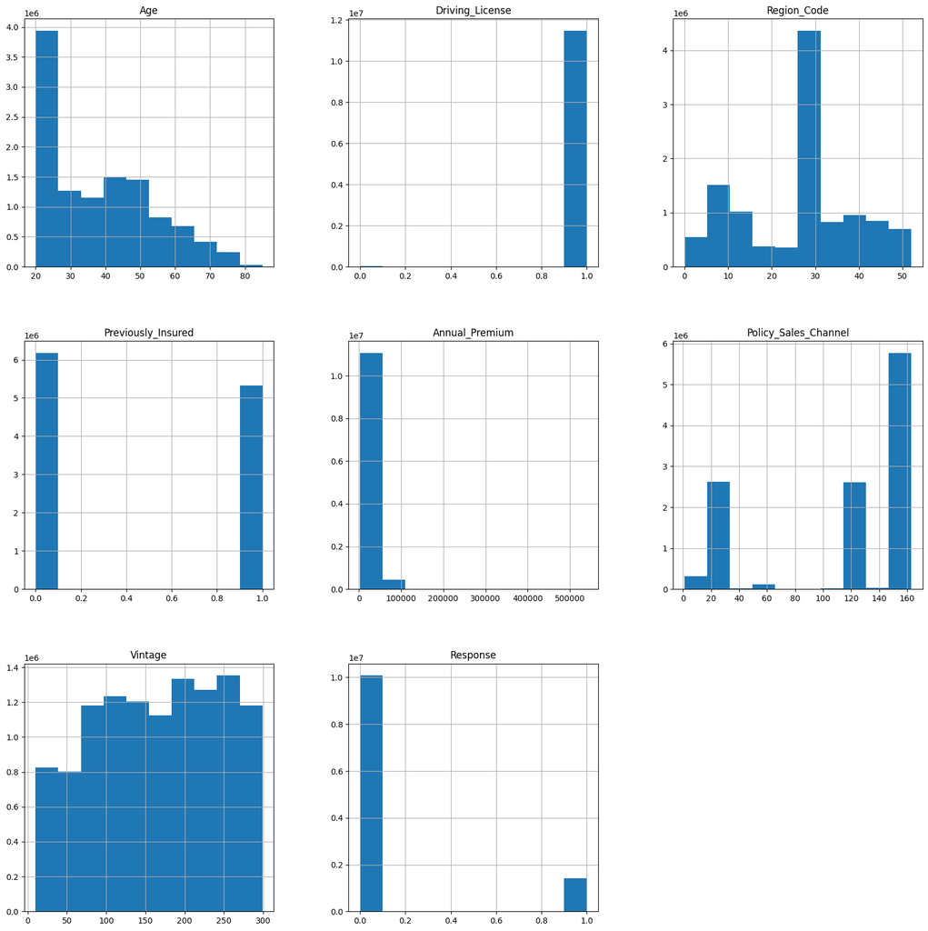

```python
train.hist(figsize=(20, 20));
```

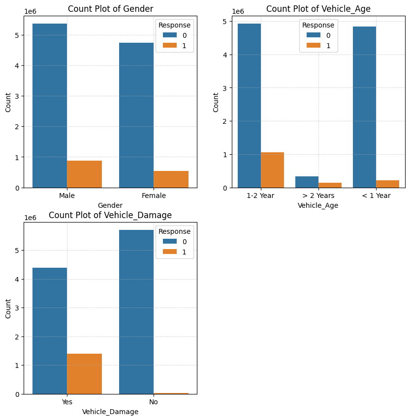

```python
categorical_features = ['Gender', 'Vehicle_Age', 'Vehicle_Damage']
plt.figure(figsize=(10,10))
for i,feature in enumerate(categorical_features,1):
    plt.subplot(2, 2, i)
    sns.countplot(data=train,x = feature,hue = 'Response')
    plt.grid(True, which='both', linestyle='--', linewidth=0.5, alpha=0.7)
    plt.title(f'Count Plot of {feature}')
    plt.xlabel(feature)
    plt.ylabel('Count')
    plt.show
```

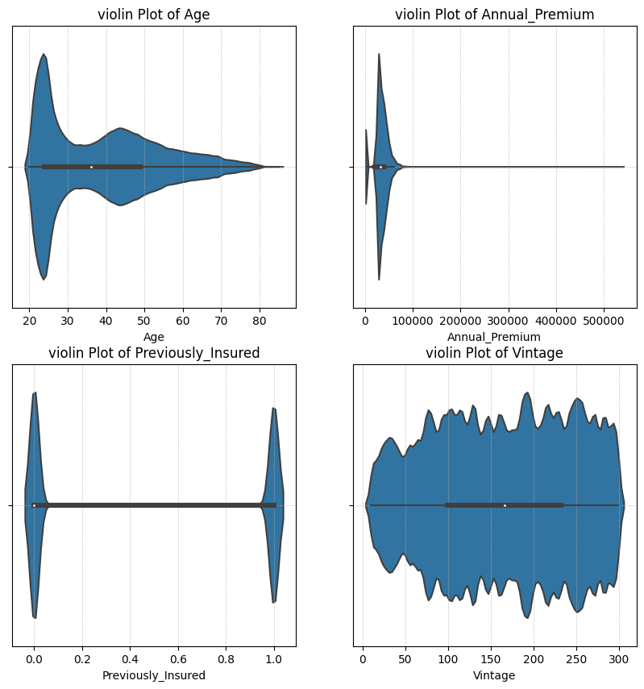

```python
plt.figure(figsize=(10,10))
numerical_features = ['Age', 'Annual_Premium','Previously_Insured', 'Vintage']
for i,feature in enumerate(numerical_features,1):
    plt.subplot(2, 2, i)
    sns.violinplot(data=train,x = feature,hue = 'Response')
    plt.grid(True, which='both', linestyle='--', linewidth=0.5, alpha=0.7)
    plt.title(f'violin Plot of {feature}')
    plt.xlabel(feature)
    plt.show
```

```python
train['Vehicle_Age'].value_counts()
```

```
Vehicle_Age
1-2 Year     5982678
< 1 Year     5044145
> 2 Years     477975
Name: count, dtype: int64
```

```python
correlation = train[['Driving_License', 'Response']].corr()
print(correlation)
correlation = train[['Annual_Premium', 'Response']].corr()
print(correlation)
correlation = train[['Previously_Insured', 'Response']].corr()
print(correlation)
correlation = train[['Vintage', 'Response']].corr()
print(correlation)
correlation = train[['Policy_Sales_Channel', 'Response']].corr()
print(correlation)
correlation = train[['Region_Code', 'Response']].corr()
print(correlation)
correlation = train[['Age', 'Response']].corr()
print(correlation)
```

```
                 Driving_License  Response
Driving_License         1.000000  0.009197
Response                0.009197  1.000000
                Annual_Premium  Response
Annual_Premium        1.000000  0.032261
Response              0.032261  1.000000
                    Previously_Insured  Response
Previously_Insured             1.00000  -0.34593
Response                      -0.34593   1.00000
           Vintage  Response
Vintage   1.000000 -0.015177
Response -0.015177  1.000000
                      Policy_Sales_Channel  Response
Policy_Sales_Channel              1.000000 -0.152733
Response                         -0.152733  1.000000
             Region_Code  Response
Region_Code     1.000000  0.012816
Response        0.012816  1.000000
               Age  Response
Age       1.000000  0.122134
Response  0.122134  1.000000
```

**Correlation between Driving License and Response is very low.**

```python
train['Driving_License'].value_counts()
```

```
Driving_License
1    11482041
0       22757
Name: count, dtype: int64
```

**Removing Column Driving License**

```python
train = train.drop('Driving_License',axis=1)
test = test.drop('Driving_License',axis=1)
```

**Creating new features to give weightage to those values which are frequently occuring**

> For Policy Sales Channel

```python
special_channels = train['Policy_Sales_Channel'].value_counts().nlargest(2).index

for channel in special_channels:
    new_feature = f'special_channel_{channel}'
    for df in [train, test]:
        df[new_feature] = (df["Policy_Sales_Channel"] == channel).astype("int8")

new_feature = 'special_channels'
for df in [train, test]:
    df[new_feature] = (
        df['Policy_Sales_Channel'].isin(special_channels)
    ).astype("int8")
```

> For Age

```python
new_feature = 'is_young_driver'
for df in [train, test]:
    df[new_feature] = ((df['Age'] >= 20) & (df['Age'] < 25)).astype('int8')

new_feature = 'is_old_driver'
for df in [train, test]:
    df[new_feature] = (df['Age'] > 61).astype('int8')
```

> For Region Code

```python
special_region = train['Region_Code'].value_counts().nlargest(2).index
new_feature = 'is_special_region'
for df in [train, test]:
    df[new_feature] = (
        df['Region_Code'].isin(special_region)
    ).astype("int8")
```

```python
print(train.shape)
train.head(5)
```

```
(11504798, 16)
```

|  | Gender | Age | Region_Code | Previously_Insured | Vehicle_Age | Vehicle_Damage | Annual_Premium | Policy_Sales_Channel | Vintage | Response | special_channel_152.0 | special_channel_26.0 | special_channels | is_young_driver | is_old_driver | is_special_region |
| --- | --- | --- | --- | --- | --- | --- | --- | --- | --- | --- | --- | --- | --- | --- | --- | --- |
| 0 | Male | 21 | 35.0 | 0 | 1-2 Year | Yes | 65101.0 | 124.0 | 187 | 0 | 0 | 0 | 0 | 1 | 0 | 0 |
| 1 | Male | 43 | 28.0 | 0 | > 2 Years | Yes | 58911.0 | 26.0 | 288 | 1 | 0 | 1 | 1 | 0 | 0 | 1 |
| 2 | Female | 25 | 14.0 | 1 | < 1 Year | No | 38043.0 | 152.0 | 254 | 0 | 1 | 0 | 1 | 0 | 0 | 0 |
| 3 | Female | 35 | 1.0 | 0 | 1-2 Year | Yes | 2630.0 | 156.0 | 76 | 0 | 0 | 0 | 0 | 0 | 0 | 0 |
| 4 | Female | 36 | 15.0 | 1 | 1-2 Year | No | 31951.0 | 152.0 | 294 | 0 | 1 | 0 | 1 | 0 | 0 | 0 |

```python
print(test.shape)
test.head(5)
```

```
(7669866, 15)
```

|  | Gender | Age | Region_Code | Previously_Insured | Vehicle_Age | Vehicle_Damage | Annual_Premium | Policy_Sales_Channel | Vintage | special_channel_152.0 | special_channel_26.0 | special_channels | is_young_driver | is_old_driver | is_special_region |
| --- | --- | --- | --- | --- | --- | --- | --- | --- | --- | --- | --- | --- | --- | --- | --- |
| 0 | Female | 20 | 47.0 | 0 | < 1 Year | No | 2630.0 | 160.0 | 228 | 0 | 0 | 0 | 1 | 0 | 0 |
| 1 | Male | 47 | 28.0 | 0 | 1-2 Year | Yes | 37483.0 | 124.0 | 123 | 0 | 0 | 0 | 0 | 0 | 1 |
| 2 | Male | 47 | 43.0 | 0 | 1-2 Year | Yes | 2630.0 | 26.0 | 271 | 0 | 1 | 1 | 0 | 0 | 0 |
| 3 | Female | 22 | 47.0 | 1 | < 1 Year | No | 24502.0 | 152.0 | 115 | 1 | 0 | 1 | 1 | 0 | 0 |
| 4 | Male | 51 | 19.0 | 0 | 1-2 Year | No | 34115.0 | 124.0 | 148 | 0 | 0 | 0 | 0 | 0 | 0 |

> **Preprocessing**

```python
categorical_features = ['Gender', 'Vehicle_Age', 'Vehicle_Damage']
numerical_features = ['Annual_Premium']
```

```python
X,y = train.drop('Response',axis=1), train['Response']
```

```python
preprocessor = ColumnTransformer(
    transformers=[('oe', OrdinalEncoder(), categorical_features),
                  ('scaler', RobustScaler(), numerical_features)],
    remainder='passthrough')

train_transformed = preprocessor.fit_transform(X)
train_transformed[0]
```

```
array([  1.       ,   0.       ,   1.       ,   2.3477494,  21.       ,
        35.       ,   0.       , 124.       , 187.       ,   0.       ,
         0.       ,   0.       ,   1.       ,   0.       ,   0.       ])
```

Applied Encoder for categorical columns and Scaler for Numerical

```python
test_transformed = preprocessor.transform(test)
test_transformed[0]
```

```
array([  0.        ,   1.        ,   0.        ,  -2.05968675,
        20.        ,  47.        ,   0.        , 160.        ,
       228.        ,   0.        ,   0.        ,   0.        ,
         1.        ,   0.        ,   0.        ])
```

**Splitting Data into train and test which will help in validation**

```python
X_train, X_test, y_train, y_test = train_test_split(train_transformed, y, test_size = 0.3, random_state = 42)
```

> **Model Training**
> - Logistic Regression

```python
lr = LogisticRegression()
lr.fit(X_train, y_train)
y_pred = lr.predict_proba(X_test)[:,1]

score = roc_auc_score(y_test, y_pred)
print(f'Score: {score}')
```

```
Score: 0.8466604981474508
```

> - XGB Classifier

```python
xgb = XGBClassifier()
xgb.fit(X_train, y_train)
y_pred = xgb.predict_proba(X_test)[:,1]

score = roc_auc_score(y_test, y_pred)
print(f'Score: {score}')
```

```
Score: 0.8780805506230185
```

> **HyperParameter Tuning of XGB Classifier**

```python
# xgb = XGBClassifier(
#     objective='binary:logistic',
#     eval_metric='auc',
#     device='cuda'
# )
# param_grid = {
#     'n_estimators': [1000, 1500],
#     'learning_rate': [0.01, 0.1],
#     'max_depth': [5, 10],
#     'min_child_weight': [10,20],
#     'subsample': [0.8, 0.9],
#     'colsample_bynode': [0.8, 0.9],
#     'reg_lambda': [10,20],
#     'tree_method': ['approx'],
#     'max_bin': [256, 512,1024],
# }
# random_search = RandomizedSearchCV(
#     estimator=xgb,
#     param_distributions=param_grid,

#     scoring='roc_auc',
#     cv=5,
#     verbose=1,
#     random_state=42,
#     n_jobs=-1
# )


# random_search.fit(X_train, y_train)
# print(f"Best parameters: {random_search.best_params_}")
# print(f"Best score: {random_search.best_score_}")
```

```python
xgb_tuned = XGBClassifier(objective='binary:logistic',
    eval_metric='auc',
    device='cuda',
    n_estimators=1500,
    learning_rate=0.1,
    max_depth=10,
    min_child_weight=25,
    subsample=0.9,
    colsample_bynode=0.9,
    reg_lambda=20,
    tree_method='approx',
    max_bin=1024

    )
xgb_tuned.fit(X_train, y_train)
y_pred = xgb_tuned.predict_proba(X_test)[:,1]

score = roc_auc_score(y_test, y_pred)
print(f'Score: {score}')
```

```
Score: 0.8838595434254661
```

LightGBM Classifier

```python
lgb_model = lgb.LGBMClassifier(learning_rate=0.2,metric='auc',num_leaves =  75,max_depth =10,    verbose=0,feature_pre_filter =True,bagging_fraction = 0.8,
                               bagging_freq =10,
                               random_state=42)

lgb_model.fit(X_train, y_train)
y_pred = lgb_model.predict_proba(X_test)[:,1]

score = roc_auc_score(y_test, y_pred)
print(f'Score: {score}')
```

```
[LightGBM] [Warning] bagging_freq is set=10, subsample_freq=0 will be ignored. Current value: bagging_freq=10
[LightGBM] [Warning] bagging_fraction is set=0.8, subsample=1.0 will be ignored. Current value: bagging_fraction=0.8
[LightGBM] [Warning] bagging_freq is set=10, subsample_freq=0 will be ignored. Current value: bagging_freq=10
[LightGBM] [Warning] bagging_fraction is set=0.8, subsample=1.0 will be ignored. Current value: bagging_fraction=0.8
[LightGBM] [Warning] bagging_freq is set=10, subsample_freq=0 will be ignored. Current value: bagging_freq=10
[LightGBM] [Warning] bagging_fraction is set=0.8, subsample=1.0 will be ignored. Current value: bagging_fraction=0.8
Score: 0.8782958954696195
```

> **Comparing Models**

```python
y_probs_log_reg = lr.predict_proba(X_test)[:, 1]
y_probs_xgb = xgb.predict_proba(X_test)[:, 1]
y_probs_xg = xgb_tuned.predict_proba(X_test)[:, 1]
y_probs_lgbm = lgb_model.predict_proba(X_test)[:, 1]

# Compute ROC curve and ROC AUC score
fpr_log_reg, tpr_log_reg, _ = roc_curve(y_test, y_probs_log_reg)
fpr_xgb, tpr_xgb, _ = roc_curve(y_test, y_probs_xgb)
fpr_xg, tpr_xg, _ = roc_curve(y_test, y_probs_xg)
fpr_lgbm, tpr_lgbm, _ = roc_curve(y_test, y_probs_lgbm)

roc_auc_log_reg = auc(fpr_log_reg, tpr_log_reg)
roc_auc_xgb = auc(fpr_xgb, tpr_xgb)
roc_auc_xg = auc(fpr_xg, tpr_xg)
roc_auc_lgbm = auc(fpr_lgbm, tpr_lgbm)
```

```
[LightGBM] [Warning] bagging_freq is set=10, subsample_freq=0 will be ignored. Current value: bagging_freq=10
[LightGBM] [Warning] bagging_fraction is set=0.8, subsample=1.0 will be ignored. Current value: bagging_fraction=0.8
```

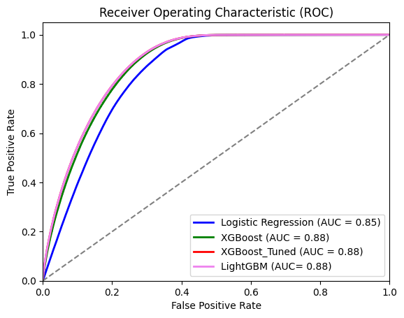

```python
plt.figure()

plt.plot(fpr_log_reg, tpr_log_reg, color='blue', lw=2, label=f'Logistic Regression (AUC = {roc_auc_log_reg:.2f})')
plt.plot(fpr_xgb, tpr_xgb, color='green', lw=2, label=f'XGBoost (AUC = {roc_auc_xgb:.2f})')
plt.plot(fpr_xg, tpr_xg, color='red', lw=2, label=f'XGBoost_Tuned (AUC = {roc_auc_xg:.2f})')
plt.plot(fpr_xg, tpr_xg, color='violet', lw=2, label=f'LightGBM (AUC= {roc_auc_lgbm:.2f})')


plt.plot([0, 1], [0, 1], color='gray', linestyle='--')
plt.xlim([0.0, 1.0])
plt.ylim([0.0, 1.05])
plt.xlabel('False Positive Rate')
plt.ylabel('True Positive Rate')
plt.title('Receiver Operating Characteristic (ROC)')
plt.legend(loc='lower right')
plt.show()
```

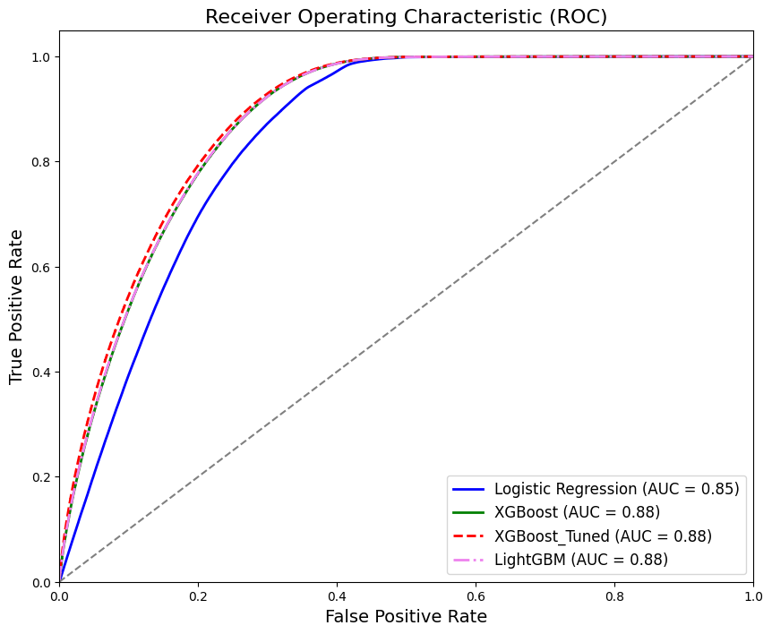

```python
plt.figure(figsize=(10, 8))

plt.plot(fpr_log_reg, tpr_log_reg, color='blue', lw=2, label=f'Logistic Regression (AUC = {roc_auc_log_reg:.2f})')
plt.plot(fpr_xgb, tpr_xgb, color='green', lw=2, label=f'XGBoost (AUC = {roc_auc_xgb:.2f})')
plt.plot(fpr_xg, tpr_xg, color='red', lw=2, linestyle='--', label=f'XGBoost_Tuned (AUC = {roc_auc_xg:.2f})')
plt.plot(fpr_lgbm, tpr_lgbm, color='violet', lw=2, linestyle='-.', label=f'LightGBM (AUC = {roc_auc_lgbm:.2f})')

plt.plot([0, 1], [0, 1], color='gray', linestyle='--')

# Set limits and labels
plt.xlim([0.0, 1.0])
plt.ylim([0.0, 1.05])
plt.xlabel('False Positive Rate', fontsize=14)
plt.ylabel('True Positive Rate', fontsize=14)
plt.title('Receiver Operating Characteristic (ROC)', fontsize=16)
plt.legend(loc='lower right', fontsize=12)
plt.show()
```

> **Creating Submission File**

```python
test_data_1 = pd.read_csv('/kaggle/input/playground-series-s4e7/test.csv')
```

```python
test_predictions = xgb_tuned.predict_proba(test_transformed)
res_df = pd.DataFrame({

   'id': test_data_1['id'],
    'Response': test_predictions[:, 1]
})
```

```python
res_df.to_csv('XGB_tuned_sub.csv', index = False)
```